# Tarea 3

### 1. Haz tu propia función llamada lagrange(n,x,y), que reciba los nodos o puntos para interpolar x,y y el grado del polinomio deseado n.

```python
# Importamos algunas librerías
import numpy as np
import matplotlib.pyplot as plt
from sympy import *
from sympy.abc import x
```

Primero definimos una función polL que toma como entrada números n,k, el conjunto de puntos xp en los que vamos a interpolar y la variable x.

PolL da como resultado la función $L_k$ evaluada en el punto x. Donde $L_k$ es el k-ésimo polinomio base como lo definimos en clase, que dados los puntos $[x_0, x_1, \cdots, x_n]$ sobre los que vamos a interpolar se define como:

$$ L_k(x) = \frac{(x - x_0) \dots (x - x_{k-1})(x - x_{k+1}) \dots (x - x_n)}{(x_k - x_0) \dots (x_k - x_{k-1})(x_k - x_{k+1}) \dots (x_k - x_n)}$$

```python
def polL(n,k,xp,x):
    # res va a ser el resultado de L_k(x)
    # Empezamos con res =1
    res = 1

    # La función Lk(x) consiste en multiplicar n+1 factores de la forma
    # (x-x_i)/(x_k-x_i)  excepto para i=k
    # Así que vamos a iterar la i desde 0 hasta n+1
    for i in range(n+1):
        # si i es distinto de k
        if i!=k:
            #multiplicamos res por el i-ésimo factor
            res*=(x-xp[i])/(xp[k]-xp[i])
    # Al terminar los productos, ya tendremos la solución
    return(res)
```

Ahora definimos una función Lagrange(n,xp,yp) que ya construye el polinomio de lagrange de orden n. Donde xp es la lista de los puntos muestra en el eje x y yp son los valores de la función que queremos interpolar en dichos puntos.

Como vimos en clase, la solución está dada por $$ P_n(x) = y_0 L_0(x) + y_1 L_1(x) + \dots + y_n L_n(x) $$

La función va a devolver el polinomio de lagrange en forma simbólica usando sympy

```python
# definimos la función
def lagrange(n,xp,yp):
    # len(xp) es la cantidad de puntos muestra que tenemos
    # El polinomio de lagrange de mayor grado que podemos contruir con len(xp) puntos
    # es de grado len(xp)-1. Así que si el usuario quiere un polinomio de grado
    # mayor a este número, automáticamente convertiremos n en este máximo posible
    if n>len(xp)-1:
        n = len(xp)-1

    # Empezamos con un resultado de 0
    res = 0



    # vamos a ir sumando los términos y_i L_i(x)
    # donde L_i(x) lo conseguimos con la función polL(x)
    # si n+1 es menor a la cantidad de puntos que hay en la muestra,
    #lo que pasará es que sólo consideraremos los primeros n+1 puntos muestra
    # y los demás serán ignorados
    for i in range(n+1):
        # la variable x la habíamos importado en from sympy.abc import x
        # por lo que es un símbolo de sympy y se va a mantener simbólico
        res += yp[i]*polL(n,i,xp,x)

    # La función expand expande este polinomio para escribirlo como
    # a_nx^n + a_{n-1}x^{n-1} + ... + a_1 x + a_0
    return(expand(res))
```

Vamos a poner a prueba nuestra función de interpolación.

Para ello, creamos 15 puntos entre 1,2 y los guardamos en Xp. Y Yp son la función tangente evaluada en Xp.

Primero vamos a imprimir el polinomio de orden 14 (el orden más grande posible para 15 puntos) conseguido con nuestra función.

Luego vamos a imprimir el mismo polinomio con la función que ya viene implementada en sympy (interpolating_poly) para ver si da el mismo polinomio

```python
# Creamos las muestras
Xp=np.linspace(1,2,15)
# evaluamos en tangente
Yp=np.tan(Xp)

# Imprimimos el polinomio encontrado por nuestra función
print('polinomio encontrado por nuestra funcion: \n', lagrange(14,Xp,Yp))

print('\n')

#ahora imprimimos el polinomio que crea Sympy con su funcion
#tomar en cuenta que la primera entrada de interpolating_poly es
# el número de puntos en la muestra Xp, no el grado del polinomio a crear (como en la nuestra)
# por lo que llamamos esta función con 15 en vez de 14
p1 = interpolating_poly(15, x, Xp, Yp) #funcion de SymPy que interpola un polinomio
print('polinomio creado por sympy \n', expand(p1))
```

```
polinomio encontrado por nuestra funcion:
 -606925472422.109*x**14 + 12702466826778.5*x**13 - 122999636432398.0*x**12 + 730348946688631.0*x**11 - 2.97085068316682e+15*x**10 + 8.75723785335037e+15*x**9 - 1.9290404648107e+16*x**8 + 3.22575504701774e+16*x**7 - 4.11473465558263e+16*x**6 + 3.98425357532009e+16*x**5 - 2.88268812228196e+16*x**4 + …


polinomio creado por sympy
 -606925472422.109*x**14 + 12702466826778.5*x**13 - 122999636432398.0*x**12 + 730348946688631.0*x**11 - 2.97085068316682e+15*x**10 + 8.75723785335037e+15*x**9 - 1.9290404648107e+16*x**8 + 3.22575504701774e+16*x**7 - 4.11473465558263e+16*x**6 + 3.98425357532009e+16*x**5 - 2.88268812228196e+16*x**4 + …
```

Vemos que dan básicamente el mismo resultado. Por lo que nuestra función parece estar bien implementada.

Lo ponemos a prueba de la misma forma que hicimos en clase. Creamos cuatro puntos de muestra de la función tangente.

Luego vamos a crear una gráfica con la función tangente y con la función dada por el polinomio interpolado de orden 3 (el máximo orden para 4 puntos). Además graficamos los puntos de la muestra que tomamos de tangente.

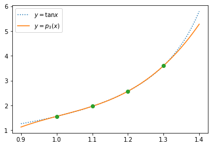

```python
X2=[1,1.1,1.2,1.3]
Y2=np.tan(X2)

# creamos los puntos x de lo que vamos a graficar
xr = np.linspace(0.9, 1.4)
# graficamos la función tangente de forma punteada
plt.plot(xr, np.tan(xr),":", label=r"$y = \tan x$")

# aplicamos nuestra función lagrange a los puntos, con un orden de 3
# para conseguir el polinomio p dados estos puntos.
# p es el polinomio escrito simbólicamente.
p =lagrange(3,X2,Y2)

# para convertir el polinomio simbólico en una función como tal,
# usamos la función lambdify de sympy. Esto lo convierte en una función de x
# y ya podemos evaluar números.
p = lambdify(x, p)

# Graficamos el polinomio de interpolación que conseguimos
plt.plot(xr, p(xr), label=r"$y = p_3(x)$")
#graficamos los puntos
plt.plot(X2, Y2, "o")

plt.legend()
```

Vemos que nuestro polinomio pasa por los 4 puntos, justo como debería. Y se acerca mucho a la tangente

Ahora la ponemos a prueba con la función seno entre -pi y pi y con 15 puntos muestra para comprobar que siga funcionando. El procedimiento es el mismo de antes pero con la función seno

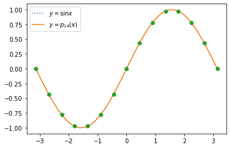

```python
#tomamos 15 puntos muestra entre -15 y 15
Xp=np.linspace(-np.pi,np.pi,15)
Yp=np.sin(Xp)

#graficamos la funcion sin
xr = np.linspace(-np.pi,np.pi)
plt.plot(xr, np.sin(xr),":", label=r"$y = \sin x$")

#calculamos nuestro polinomio de orden 14 y lo graficamos
p =lagrange(14,Xp,Yp)
p = lambdify(x, p)
plt.plot(xr, p(xr), label=r"$y = p_{14}(x)$")

#graficamos los puntos muestra
plt.plot(Xp, Yp, "o")



plt.legend()
```

Vemos que las dos gráficas coinciden casi perfectamente, nuestro polinomio funciona muy bien. Incluso, si imprimimos el polinomio para el seno, vemos que se parece bastante a los primeros términos de la serie de Taylor, lo que tiene sentido: $$ \sin(x) \simeq x - \dfrac{1}{6}x^3 + \dfrac{1}{120}x^5 - \dfrac{1}{5040} x^7+ \cdots$$

```python
print(lagrange(14,Xp,Yp))
```

```
1.40355572216672e-10*x**13 - 2.48393317650586e-8*x**11 + 5.55111512312578e-17*x**10 + 2.75464190796493e-6*x**9 - 0.000198409876512873*x**7 - 8.88178419700125e-16*x**6 + 0.00833332983196278*x**5 - 0.166666664898044*x**3 + 0.999999999764481*x
```

También implementé un algoritmo para ir viendo como se actualiza el polinomio de interpolación para la función seno conforme se aumentan los puntos muestra.

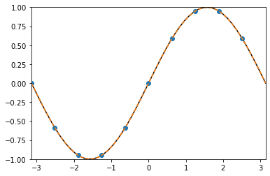

```python
# importamos algunas cosas más
from IPython import display
import time
import random

#creamos una serie de puntos entre -pi y pi
xr = np.linspace(-np.pi,np.pi)

# definimos una función que grafica puntos muestra, el polinomio y el seno
def visual(Xp,Yp,p):
    plt.plot(xr, p(xr), 'k', label='y = p{}(x)$'.format(len(Xp)-1))
    plt.plot(Xp, Yp, "o")
    plt.xlim(-np.pi,np.pi)
    plt.ylim(-1,1)
    plt.plot(xr,np.sin(xr),'--')
    display.clear_output(wait=True)

    plt.show()


# vamos a ir agregando puntos hasta tener maxx puntos
maxx = 10

plt.figure(figsize=(12, 5))

#empezamos con un solo punto -pi
Xp = [-np.pi]

# vamos a ir agregando puntos y cada vez vamos actualizando el polinomio
# y lo graficamos de nuevo
for i in range(2,maxx+1):
    # agregamos puntos alternativamente al inicio y final del intervalo [-pi,pi]
    if i%2 == 0:
        Xp.append(-np.pi + 2*np.pi/maxx*(i//2))
    else:
        Xp.append(np.pi - 2*np.pi/maxx*(i//2))

    Yp = np.sin(Xp)

    #creamos el polinomio de lagrange
    p = lagrange(i,Xp,Yp)

    #graficamos
    visual(Xp,Yp,lambdify(x,p))
    # esperamos antes de actualizar la gráfica
    time.sleep(0.6)


plt.clf()
```

# 2

**Sea $f(x) = 2 \sin(\pi x / 6)$ (con el ángulo medido en radianes)**

**a) Use el polinomio de Lagrange P2 con nodos $x_0 = 0, x_1 =1, x_2 = 3$ para aproximar $f(2)$ y $f(2.4)$**

Simplemente creamos la muestra de puntos formada por xp = [0,1,3] y sus resultados yp al evaluar en f(x)

Luego creamos el polinomio de lagrange asociado (de orden 2). Y lo evaluamos en los puntos desconocidos (2 y 2.4). Finalmente, graficamos la función f(x) y el polinomio, junto con los puntos.

```
Aproximación de f(2) usando p2:  1.6666666666666723
Verdadero valor de f(2):  1.7320508075688772


Aproximación de f(2.4) usando p2:  1.8400000000000065
Verdadero valor de f(2.4):  1.902113032590307
```

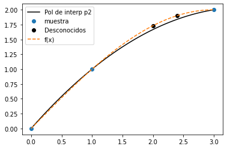

```python
# definimos la función
def f(x):
    return(2*np.sin(np.pi/6 * x))

# Creamos los puntos de la muestra
xp=np.array([0,1,3])
yp=f(xp)

# creamos el polinomio usando nuestra función lagrange
# y usando lambdify para poder evaluar puntos en él
p2 = lambdify(x,lagrange(2,xp,yp))

# evaluamos el polinomio y f en los puntos desconocidos
print('Aproximación de f(2) usando p2: ', p2(2))
print('Verdadero valor de f(2): ', f(2))
print('\n')
print('Aproximación de f(2.4) usando p2: ',p2(2.4))
print('Verdadero valor de f(2.4): ', f(2.4))

# graficamos las funciones y los puntos
xr = np.linspace(0,3)
plt.plot(xr, p2(xr), 'k', label="Pol de interp p2")
plt.plot(xp, yp, "o",label="muestra")
plt.plot([2,2.4],[f(2),f(2.4)],"ko",label="Desconocidos")

plt.plot(xr,f(xr),"--",label="f(x)")
plt.legend()

plt.show()
```

Vemos que usar el polinomio de polarización da una aproximación decentemente buena

**b) Use el polinomio de Lagrange P3 con nodos $x_0 = 0, x_1 =1, x_2 = 3,x_3=5$ para aproximar $f(2)$ y $f(2.4)$**

Hacemos el mismo procedimiento que arriba pero ahora con 4 puntos y el polinomio es de orden 3

```
Aproximación de f(2) usando p3:  1.7000000000000073
Verdadero valor de f(2):  1.7320508075688772


Aproximación de f(2.4) usando p2:  1.873600000000009
Verdadero valor de f(2.4):  1.902113032590307
```

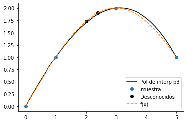

```python
def f(x):
    return(2*np.sin(np.pi/6 * x))
xp=np.array([0,1,3,5])
yp=f(xp)


p3 = lambdify(x,lagrange(3,xp,yp))


# evaluamos el polinomio y f en los puntos desconocidos
print('Aproximación de f(2) usando p3: ', p3(2))
print('Verdadero valor de f(2): ', f(2))
print('\n')
print('Aproximación de f(2.4) usando p2: ',p3(2.4))
print('Verdadero valor de f(2.4): ', f(2.4))

# graficamos entre 0 y 5 la función, el polinomio y los puntos
xr = np.linspace(0,5)
plt.plot(xr, p3(xr), 'k', label="Pol de interp p3")
plt.plot(xp, yp, "o",label="muestra")
plt.plot([2,2.4],[f(2),f(2.4)],"ko",label="Desconocidos")

plt.plot(xr,f(xr),"--",label="f(x)")
plt.legend()

plt.show()
```

Vemos que ahora el polinomio da una mejor aproximación que antes, esto porque nos dieron un poco más de información y el polinomio es de mayor orden.

**c) Use el polinomio de Lagrange P2 con nodos $x_0 = 0, x_1 =1, x_2 = 3$ para aproximar $f(4)$ y $f(3.5)$**

Nuevamente hacemos lo mismo que en las dos anteriores, y ahora evaluamos en estos otros puntos

```
Aproximación de f(4) usando p2:  2.0000000000000084
Verdadero valor de f(4):  1.7320508075688774


Aproximación de f(3.5) usando p2:  2.041666666666675
Verdadero valor de f(3.5):  1.9318516525781366
```

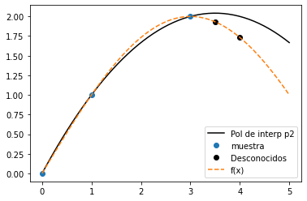

```python
def f(x):
    return(2*np.sin(np.pi/6 * x))
xp=np.array([0,1,3])
yp=f(xp)


p2 = lambdify(x,lagrange(2,xp,yp))


# evaluamos el polinomio y f en los puntos desconocidos
print('Aproximación de f(4) usando p2: ', p2(4))
print('Verdadero valor de f(4): ', f(4))
print('\n')
print('Aproximación de f(3.5) usando p2: ',p2(3.5))
print('Verdadero valor de f(3.5): ', f(3.5))

# graficamos entre 0 y 5
xr = np.linspace(0,5)
plt.plot(xr, p2(xr), 'k', label="Pol de interp p2")
plt.plot(xp, yp, "o",label="muestra")
plt.plot([3.5,4],[f(3.5),f(4)],"ko",label="Desconocidos")

plt.plot(xr,f(xr),"--",label="f(x)")
plt.legend()

plt.show()
```

Vemos que el polinomio no da una buena aproximación de los puntos desconocidos. Esto se debe a que los puntos en los que queremos evaluar la función están fuera del intervalo formado por los puntos de muestra. Y el polinomio de interpolación suele ser mejor para aproximar valores dentro de este intervalo, no fuera

**d) Use el polinomio de Lagrange P3 con nodos $x_0 = 0, x_1 =1, x_2 = 3,x_3=5$ para aproximar $f(4)$ y $f(3.5)$**

Volvemos a hacer lo mismo que antes, pero ahora con los 4 puntos dados, y usaremos un polinomio de orden 3

```
Aproximación de f(4) usando p3:  1.8000000000000176
Verdadero valor de f(4):  1.7320508075688774


Aproximación de f(3.5) usando p3:  1.9687500000000147
Verdadero valor de f(3.5):  1.9318516525781366
```

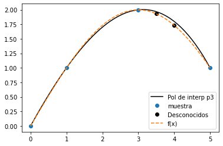

```python
# definimos la función
def f(x):
    return(2*np.sin(np.pi/6 * x))
# los puntos muestra
xp=np.array([0,1,3,5])
yp=f(xp)

# creamos nuestro pol de interpolación
p3 = lambdify(x,lagrange(3,xp,yp))


# evaluamos el polinomio y f en los puntos desconocidos
print('Aproximación de f(4) usando p3: ', p3(4))
print('Verdadero valor de f(4): ', f(4))
print('\n')
print('Aproximación de f(3.5) usando p3: ',p3(3.5))
print('Verdadero valor de f(3.5): ', f(3.5))

# graficamos entre 0 y 5
xr = np.linspace(0,5)
plt.plot(xr, p3(xr), 'k', label="Pol de interp p3")
plt.plot(xp, yp, "o",label="muestra")
plt.plot([3.5,4],[f(3.5),f(4)],"ko",label="Desconocidos")

plt.plot(xr,f(xr),"--",label="f(x)")
plt.legend()

plt.show()
```

Vemos que las aproximaciones son mejores que antes. Esto porque ahora los puntos desconocidos sí están dentro del intervalo de los puntos muestra que nos dan.